# Guided Exercise 4

Zhirui Zhang, Aaron Guo

12/16/2021

## The Case

1. Increase the average SAT score to 1300
2. Enroll at least 200 more students with incomes less than $50,000
3. Don’t allow tuition revenues from first-year students to drop to less than $30 million
4. Keep the number of enrolled students between 1,450 and 1,550

## Your Job

Your job is to come up with a strategy to accomplish the administration’s goals. You’ll need to incorporate the following elements into your two page memo for the president and the board of trustees. Use conditional means to describe the probability of enrolling once admitted (yield) for different groups of students. Create a model that accurately predicts the yield for admitted students. Describe the accuracy of this model and its key findings clearly. Use the estimates from this model to adjust the current pricing strategy to induce other students to enroll, given the above constraints.Describe your approach clearly. Predict the results of your change in pricing strategy. There are lots of ways to accomplish all of the above. Remember that you need to write up your findings in a nice narrative, including charts and tables to make your key points. If you think there are some ethical implications to your approach, describe those as well.

## What to Submit

The document describing the above should be 2-4 pages. You can “knit” the document in html or pdf from Rmarkdown, or you can create a separate Word (google doc) or pdf document. You need to submit BOTH your Rmd file AND your written summary.

## Cleaning up

```r
# Clear variables
rm(list=ls())
# Clear all plots
graphics.off()
# Clear the console
cat("\014")
```

```r
# Automatically set directory
if (Sys.info()[[4]] == "AaronGuo-MacBookPro") {
  setwd("~/Programming/Vanderbilt/DS/DS1000/projects/DS-1000/")
}
```

## Set up

```r
library(modelr)
library(tidyverse)
library(tidymodels)
library(knitr)
```

```r
ad<-read_rds("admit_data.rds")%>%
  ungroup()
```

# Part 1: Use conditional means to describe yield by different groups

```r
# by income
ad_income <- ad %>%
  mutate(income_decile = ntile(income, 10)) %>%
  group_by(income_decile) %>%
  summarize(min_income = min(income),
            pct_yield = mean(yield)) %>%
  ungroup()

ad_income
```

```
## # A tibble: 10 × 3
##    income_decile min_income pct_yield
##            <int>      <dbl>     <dbl>
##  1             1      8844.     0.205
##  2             2     41483.     0.265
##  3             3     55177.     0.447
##  4             4     68818.     0.591
##  5             5     82099.     0.651
##  6             6     99895.     0.809
##  7             7    119776.     0.884
##  8             8    143791.     0.967
##  9             9    178036.     1
## 10            10    241071.     1
```

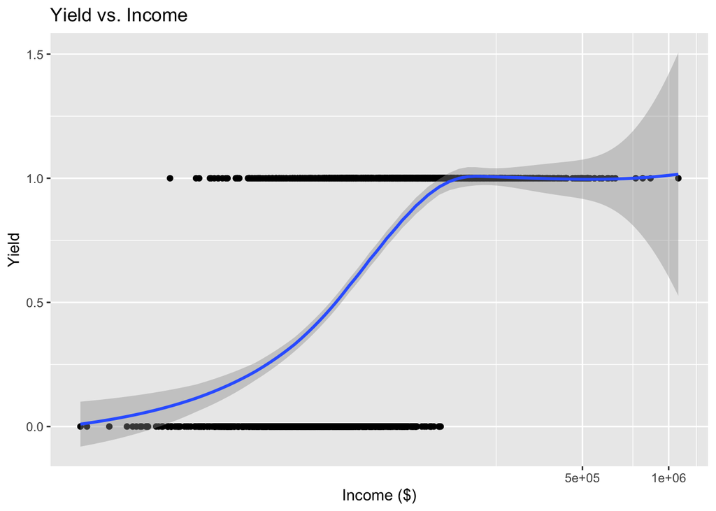

```r
# plot income vs yield
ad %>%
  ggplot(aes(x=income, y=yield)) +
  geom_point() +
  geom_smooth() +
  coord_trans(x='log10') +
  labs(x="Income ($)", y="Yield", title = "Yield vs. Income")
```

```r
# by sat
ad_sat <- ad %>%
  mutate(sat_decile = ntile(sat, 10)) %>%
  group_by(sat_decile) %>%
  summarize(min_sat = min(sat),
            pct_yield = mean(yield)) %>%
  ungroup()

ad_sat
```

```
## # A tibble: 10 × 3
##    sat_decile min_sat pct_yield
##         <int>   <dbl>     <dbl>
##  1          1   1000      0.405
##  2          2   1072.     0.474
##  3          3   1114.     0.488
##  4          4   1145.     0.577
##  5          5   1173.     0.581
##  6          6   1200.     0.8
##  7          7   1227.     0.819
##  8          8   1252.     0.837
##  9          9   1285.     0.884
## 10         10   1329.     0.953
```

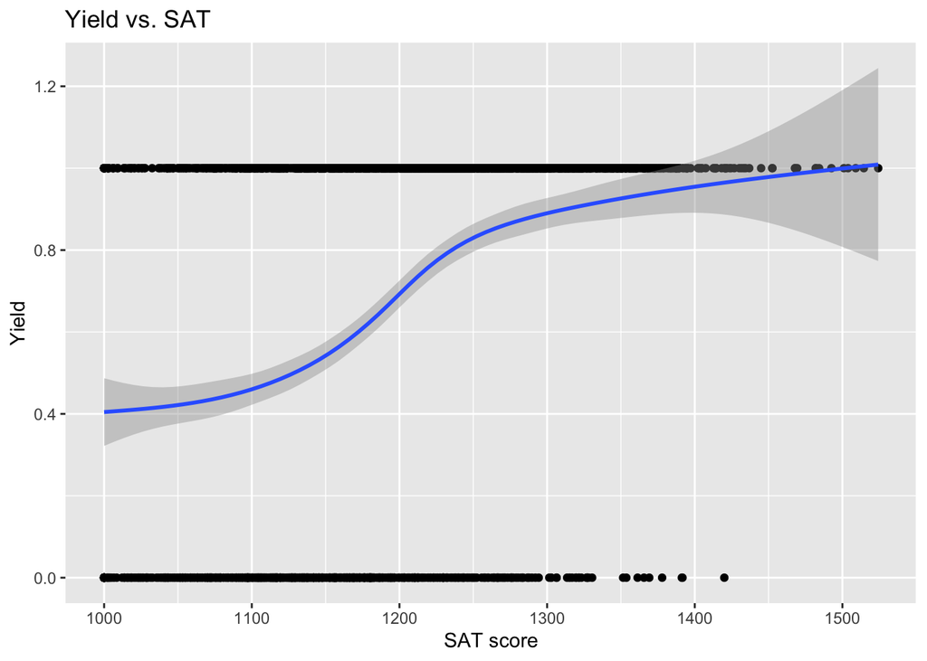

```r
ad %>%
  ggplot(aes(x=sat, y=yield)) +
  geom_point() +
  geom_smooth() +
  labs(x="SAT score", y="Yield", title = "Yield vs. SAT")
```

```r
# by gpa
ad_gpa <- ad %>%
  mutate(gpa_decile = ntile(gpa, 10)) %>%
  group_by(gpa_decile) %>%
  summarize(min_gpa = min(gpa),
            pct_yield = mean(yield)) %>%
  ungroup()

ad_gpa
```

```
## # A tibble: 10 × 3
##    gpa_decile min_gpa pct_yield
##         <int>   <dbl>     <dbl>
##  1          1    2.8      0.456
##  2          2    3.43     0.521
##  3          3    3.55     0.595
##  4          4    3.64     0.609
##  5          5    3.72     0.637
##  6          6    3.79     0.730
##  7          7    3.86     0.749
##  8          8    3.94     0.795
##  9          9    4        0.865
## 10         10    4        0.860
```

```r
# by visit
ad_visit <- ad %>%
  group_by(visit) %>%
  summarize(pct_yield = mean(yield)) %>%
  ungroup()

ad_visit
```

```
## # A tibble: 2 × 2
##   visit pct_yield
##   <dbl>     <dbl>
## 1     0     0.644
## 2     1     0.736
```

```r
# by legacy
ad_legacy <- ad %>%
  group_by(legacy) %>%
  summarize(pct_yield = mean(yield)) %>%
  ungroup()

ad_legacy
```

```
## # A tibble: 2 × 2
##   legacy pct_yield
##    <dbl>     <dbl>
## 1      0     0.641
## 2      1     0.780
```

```r
# by registered
ad_registered <- ad %>%
  group_by(sent_scores) %>%
  summarize(pct_yield = mean(yield)) %>%
  ungroup()

ad_registered
```

```
## # A tibble: 2 × 2
##   sent_scores pct_yield
##         <dbl>     <dbl>
## 1           0     0.651
## 2           1     0.805
```

```r
# by distance
ad_distance <- ad %>%
  mutate(log_distance_decile = ntile(log(distance), 10)) %>%
  group_by(log_distance_decile) %>%
  summarize(min_distance = min(distance),
            pct_yield = mean(yield)) %>%
  ungroup()

ad_distance
```

```
## # A tibble: 10 × 3
##    log_distance_decile min_distance pct_yield
##                  <int>        <dbl>     <dbl>
##  1                   1         2.70     0.716
##  2                   2        28.4      0.656
##  3                   3        43.5      0.684
##  4                   4        59.2      0.628
##  5                   5        78.5      0.698
##  6                   6       100.       0.670
##  7                   7       128.       0.730
##  8                   8       169.       0.674
##  9                   9       229.       0.670
## 10                  10       375.       0.693
```

```r
# by net price
ad_net_price <- ad %>%
  mutate(net_price_decile = ntile(net_price, 10)) %>%
  group_by(net_price_decile) %>%
  summarize(min_price = min(net_price),
            pct_yield = mean(yield)) %>%
  ungroup()

ad_net_price
```

```
## # A tibble: 10 × 3
##    net_price_decile min_price pct_yield
##               <int>     <dbl>     <dbl>
##  1                1        0      0.512
##  2                2        0      0.786
##  3                3     9464.     0.884
##  4                4    11689.     0.921
##  5                5    13053.     0.926
##  6                6    14109.     0.414
##  7                7    22505.     0.279
##  8                8    31248.     0.419
##  9                9    43766.     0.819
## 10               10    45000      0.860
```

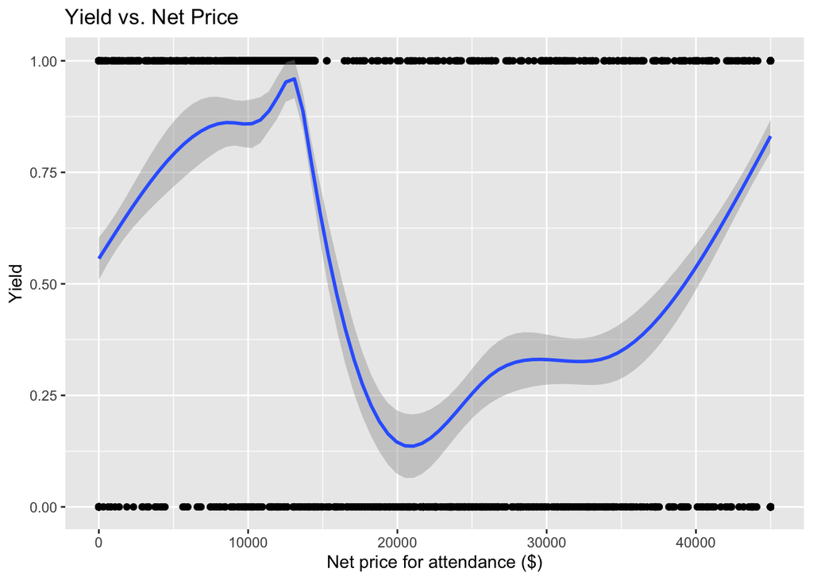

```r
ad %>%
  ggplot(aes(x=net_price, y=yield)) +
  geom_point() +
  geom_smooth() +
  labs(x="Net price for attendance ($)", y="Yield", title="Yield vs. Net Price")
```

## Part 1.2: Analysis of students from low-income households (<$50.000/year)

### Data Wrangling

```r
ad<-ad%>%
  mutate(yield_f=as_factor(ifelse(yield==1,"Yes","No")))%>%
  mutate(yield_f=relevel(yield_f,ref="No"))%>%
    mutate(sat=sat/100,
         income=income/1000,
         distance=distance/1000,
         net_price=net_price/1000)
```

### Filter out low-income students (income < $50,000)

```r
ad_lowincome <- ad %>%
  filter(income < 50000/1000)
```

### Split the data for analysis

```r
# set seed
set.seed(6666)

split_data_glm <- initial_split(ad_lowincome)

ad_train_glm <- training(split_data_glm)

ad_test_glm <- testing(split_data_glm)
```

### Logistical regression analysis

```r
logit_mod<-logistic_reg()%>%
  set_engine("glm")%>%
  set_mode("classification")

admit_formula <- as.formula(
                  "yield_f~
                          legacy+
                          visit+
                          registered+
                          sent_scores+
                          sat+
                          income+
                          gpa+
                          distance+
                          net_price")

admit_recipe<-recipe(admit_formula,ad)%>%
  step_log(distance)

ad_wf<-workflow()%>%
  add_model(logit_mod)%>%
  add_recipe(admit_recipe)

ad_result<-ad_wf%>%
  fit(ad_train_glm)

tidy(ad_result)
```

```
## # A tibble: 10 × 5
##    term        estimate std.error statistic   p.value
##    <chr>          <dbl>     <dbl>     <dbl>     <dbl>
##  1 (Intercept) -11.3       4.04      -2.80  0.00515
##  2 legacy        0.218     0.449      0.487 0.627
##  3 visit         0.263     0.356      0.738 0.461
##  4 registered    0.628     0.333      1.89  0.0593
##  5 sent_scores   0.600     0.473      1.27  0.205
##  6 sat           0.137     0.344      0.399 0.690
##  7 income        0.0548    0.0206     2.66  0.00772
##  8 gpa           1.16      0.848      1.37  0.171
##  9 distance     -0.837     0.201     -4.17  0.0000307
## 10 net_price    -0.0568    0.0304    -1.87  0.0617
```

### Getting ROC

```r
# generate prediction
ad_wf_glm_pred <- ad_result %>%
  predict(ad_test_glm) %>%
  bind_cols(ad_test_glm)
```

```r
ad %>%
  summarize(mean_yield = mean(yield))
```

```
##   mean_yield
## 1  0.6818605
```

```r
# accuracy
ad_wf_glm_pred %>%
  accuracy(truth=yield_f, estimate=.pred_class, event_level="second")
```

```
## # A tibble: 1 × 3
##   .metric  .estimator .estimate
##   <chr>    <chr>          <dbl>
## 1 accuracy binary         0.872
```

```r
# sensitivity
ad_wf_glm_pred %>%
  sens(truth=yield_f, estimate=.pred_class, event_level="second")
```

```
## # A tibble: 1 × 3
##   .metric .estimator .estimate
##   <chr>   <chr>          <dbl>
## 1 sens    binary           0.5
```

```r
# specificity
ad_wf_glm_pred %>%
  spec(truth=yield_f, estimate=.pred_class, event_level="second")
```

```
## # A tibble: 1 × 3
##   .metric .estimator .estimate
##   <chr>   <chr>          <dbl>
## 1 spec    binary         0.957
```

```r
# ROC curve
ad_wf_glm_roc <- ad_result %>%
  predict(ad_test_glm, type="prob") %>%
  bind_cols(ad_test_glm)
```

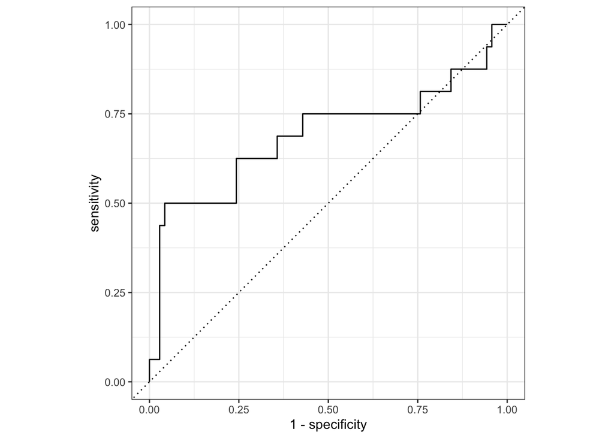

```r
ad_wf_glm_roc %>%
  roc_curve(truth=yield_f, .estimate=.pred_Yes, event_level="second") %>%
  autoplot()
```

```r
ad_wf_glm_roc %>%
  roc_auc(truth=yield_f, .estimate=.pred_Yes, event_level="second")
```

```
## # A tibble: 1 × 3
##   .metric .estimator .estimate
##   <chr>   <chr>          <dbl>
## 1 roc_auc binary         0.688
```

```r
# Extract results
ad_fit <- ad_result %>% extract_fit_parsnip()
```

### what if the net price is negative

```r
hypo_data <- ad_lowincome %>%
  # supply the mode (for each variable) of the entire dataset
  data_grid(.model=ad_fit$fit,
            net_price = seq(from=-5, to=0, by=0.05))
```

```r
ad_negativeprice <- ad_result%>%
  predict(hypo_data,type="prob")%>%
  bind_cols(hypo_data)
```

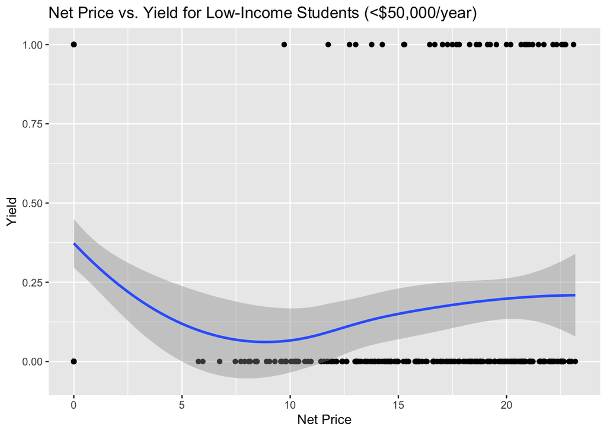

```r
ad_lowincome %>%
  ggplot(aes(x=net_price, y=yield)) +
  geom_point() +
  geom_smooth() +
  labs(x="Net Price", y="Yield", title="Net Price vs. Yield for Low-Income Students (<$50,000/year)")
```

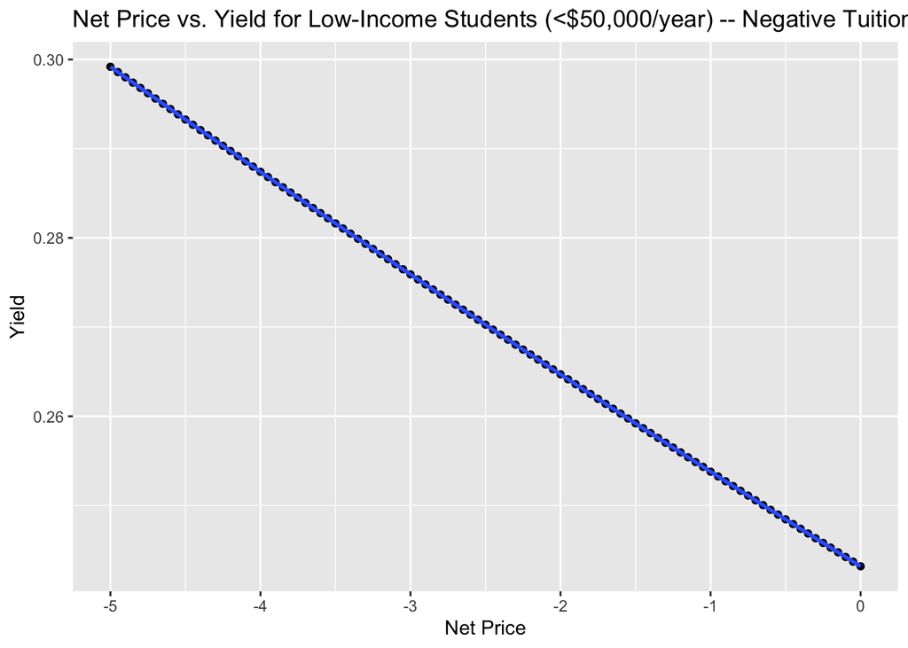

```r
ad_negativeprice %>%
  ggplot(aes(x=net_price, y=.pred_Yes)) +
  geom_point() +
  geom_smooth() +
    labs(x="Net Price", y="Yield", title="Net Price vs. Yield for Low-Income Students (<$50,000/year) -- Negative Tuition")
```

# Part 2: Create a model to predict yield, and describe accuracy

### Split Data

```r
split_data_glm <- initial_split(ad)

ad_train_glm <- training(split_data_glm)

ad_test_glm <- testing(split_data_glm)
```

### Setting the Regression Model

```r
logit_mod<-logistic_reg()%>%
  set_engine("glm")%>%
  set_mode("classification")
```

Create formula and recipe:

```r
admit_formula <- as.formula(
                  "yield_f~
                          legacy+
                          visit+
                          registered+
                          sent_scores+
                          sat+
                          income+
                          gpa+
                          distance+
                          net_price")

admit_recipe<-recipe(admit_formula,ad)%>%
  step_log(distance)
```

add workflow:

```r
ad_wf<-workflow()%>%
  add_model(logit_mod)%>%
  add_recipe(admit_recipe)
```

fit the model:

```r
ad_result<-ad_wf%>%
  fit(ad_train_glm)
```

see the results:

```r
tidy(ad_result)
```

```
## # A tibble: 10 × 5
##    term        estimate std.error statistic  p.value
##    <chr>          <dbl>     <dbl>     <dbl>    <dbl>
##  1 (Intercept) -10.7      1.80       -5.95  2.66e- 9
##  2 legacy        0.554    0.177       3.13  1.73e- 3
##  3 visit         0.308    0.159       1.94  5.22e- 2
##  4 registered    0.502    0.153       3.29  1.00e- 3
##  5 sent_scores   0.727    0.208       3.50  4.66e- 4
##  6 sat          -0.0881   0.147      -0.599 5.49e- 1
##  7 income        0.0523   0.00363    14.4   4.18e-47
##  8 gpa           1.97     0.393       5.00  5.59e- 7
##  9 distance     -0.488    0.0806     -6.05  1.43e- 9
## 10 net_price    -0.0565   0.00879    -6.43  1.29e-10
```

### Getting ROC

```r
# generate prediction
ad_wf_glm_pred <- ad_result %>%
  predict(ad_test_glm) %>%
  bind_cols(ad_test_glm)
```

```r
ad %>%
  summarize(mean_yield = mean(yield))
```

```
##   mean_yield
## 1  0.6818605
```

```r
# accuracy
ad_wf_glm_pred %>%
  accuracy(truth=yield_f, estimate=.pred_class, event_level="second")
```

```
## # A tibble: 1 × 3
##   .metric  .estimator .estimate
##   <chr>    <chr>          <dbl>
## 1 accuracy binary         0.836
```

```r
# sensitivity
ad_wf_glm_pred %>%
  sens(truth=yield_f, estimate=.pred_class, event_level="second")
```

```
## # A tibble: 1 × 3
##   .metric .estimator .estimate
##   <chr>   <chr>          <dbl>
## 1 sens    binary         0.859
```

```r
# specificity
ad_wf_glm_pred %>%
  spec(truth=yield_f, estimate=.pred_class, event_level="second")
```

```
## # A tibble: 1 × 3
##   .metric .estimator .estimate
##   <chr>   <chr>          <dbl>
## 1 spec    binary         0.785
```

```r
# ROC curve
ad_wf_glm_roc <- ad_result %>%
  predict(ad_test_glm, type="prob") %>%
  bind_cols(ad_test_glm)
```

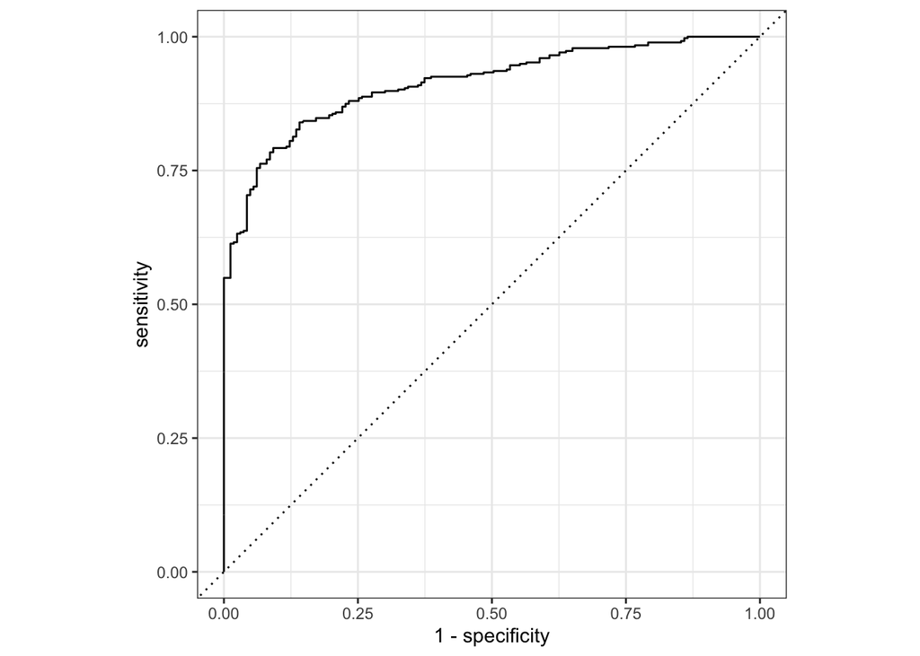

```r
ad_wf_glm_roc %>%
  roc_curve(truth=yield_f, .estimate=.pred_Yes, event_level="second") %>%
  autoplot()
```

```r
ad_wf_glm_roc %>%
  roc_auc(truth=yield_f, .estimate=.pred_Yes, event_level="second")
```

```
## # A tibble: 1 × 3
##   .metric .estimator .estimate
##   <chr>   <chr>          <dbl>
## 1 roc_auc binary         0.913
```

### Getting the baselines

The average SAT score: 1225

```r
ad%>%
  filter(yield==1)%>% #only focus on students that actually showed up
  summarize(mean(sat) * 100)
```

```
##   mean(sat) * 100
## 1        1225.941
```

we also want to see how many students have a SAT score that is higher than 1300, and how many in each group (>=1300 or <1300) enrolled

```r
# count enrollment by sat
ad %>%
  group_by(sat>=13, yield) %>%
  count()
```

```
## # A tibble: 4 × 3
## # Groups:   sat >= 13, yield [4]
##   `sat >= 13` yield     n
##   <lgl>       <int> <int>
## 1 FALSE           0   655
## 2 FALSE           1  1152
## 3 TRUE            0    29
## 4 TRUE            1   314
```

Number of currently enrolled students who come from families that make less than $50,000 a year: 77; while there are 341 low-income students in total - We did not capture 264 of these students

```r
ad%>%
  filter(yield==1,income<50)%>%
  count()
```

```
##    n
## 1 77
```

```r
ad%>%
  filter(income<50)%>%
  count()
```

```
##     n
## 1 341
```

Amount of total revenue collected from first-year students:$30,674,149

```r
ad%>%
  filter(yield==1)%>%
  summarize(dollar(sum(net_price) * 1000))
```

```
##   dollar(sum(net_price) * 1000)
## 1                   $30,674,149
```

Number of students currently yield: 1466

```r
ad%>%
  filter(yield==1)%>%
  count()
```

```
##      n
## 1 1466
```

### Part 3: Changing Policies

Look at SAT first:

```r
# generate prediction from our model
ad_pred <- ad_result%>%
  predict(ad)%>%
  bind_cols(ad)

# check predicted enrollment based on whether SAT is higher than 1300
ad_pred %>%
  group_by(sat >= 13, .pred_class)%>%
  count()
```

```
## # A tibble: 4 × 3
## # Groups:   sat >= 13, .pred_class [4]
##   `sat >= 13` .pred_class     n
##   <lgl>       <fct>       <int>
## 1 FALSE       No            693
## 2 FALSE       Yes          1114
## 3 TRUE        No             11
## 4 TRUE        Yes           332
```

```r
# ad_np%>%
#   filter(.pred_class=="Yes")%>%
#   summarize(mean(sat))
# ad_pred_1 <- ad_pred %>%
#   filter(sat < 13 & .pred_class=="No")
# ad_pred_2 <- ad_pred %>%
#   filter(sat < 13 & .pred_class=="Yes")
# ad_pred_3 <- ad_pred %>%
#   filter(sat > 13 & .pred_class=="No")
# ad_predp_4 <- ad_pred %>%
#   filter(sat > 13 & .pred_class=="Yes")
# ad_pred_combined <- rbind(ad_pred_1, ad_pred_2, ad_pred_3)
ad_pred_filtered <- ad_pred %>%
  filter(sat >= 13 | .pred_class=="Yes") %>% #to have students who either yielded or have scores >=1300
  summarize(mean(sat * 100))
ad_pred_filtered
```

```
## # A tibble: 1 × 1
##   `mean(sat * 100)`
##               <dbl>
## 1             1234.
```

Even if we admit all students who either yielded or have scores >=1300, the average SAT is increased to 1235 but still below the expected level.

```r
ad_np<-ad%>%
  mutate(net_price=ifelse(sat>=13,
                              net_price - (sat-13)*30,
                              net_price - (sat-13)*20))
ad_np <- ad_np %>%
  mutate(net_price=ifelse(net_price<0,0,net_price)) #if anybody has a net price of 0, change it to 0, otherwise leave it as it is-> because we don't charge people negative tuition!

ad_np <- ad_np %>%
  mutate(net_price = ifelse(income <= 50, -28, net_price)) #allow negative net price, meaning that the school will give scholarship to those low-income students to attract them

ad_np <- ad_np%>%
  mutate(net_price = ifelse(income >= 180, 50, net_price)) #charge high-income students more money to balance our budget and total number of enrolled students
```

### Generate predictions for the new policy

```r
# generate predictions
ad_np<-ad_result%>%
  predict(ad_np)%>%
  bind_cols(ad_np)
```

```r
# calculate the total revenue to the school from students now predicted to enroll
ad_np%>%
  filter(.pred_class=="Yes")%>%
  summarize(dollar(sum(net_price)*1000))
```

```
## # A tibble: 1 × 1
##   `dollar(sum(net_price) * 1000)`
##   <chr>
## 1 $31,660,936
```

```r
# calculate the SAT average for students now predicted to enroll
ad_np%>%
  filter(.pred_class=="Yes")%>%
  summarize(mean(sat)*100)
```

```
## # A tibble: 1 × 1
##   `mean(sat) * 100`
##               <dbl>
## 1             1236.
```

```r
# calculate how many students are now predicted to enroll
ad_np %>%
  filter(.pred_class=="Yes") %>%
  count()
```

```
## # A tibble: 1 × 1
##       n
##   <int>
## 1  1456
```

```r
# calculate how many low income students are now predicted to enroll
ad_np %>%
  filter(.pred_class=="Yes") %>%
  filter(income<=50)%>%
  count()
```

```
## # A tibble: 1 × 1
##       n
##   <int>
## 1   279
```